# Introduction to Tidy Census

Connor Gilroy and Neal Marquez

2/2/2020

# What is `tidycensus`?

`tidycensus` is an `R` package that allows users to interface with the US Census Bureau’s decennial Census and five-year American Community **APIs** and return tidyverse-ready data frames.

`tidycensus` is created and maintained by Kyle Walker, a professor in geography at TCU.

# The census has an API???

Yes but with limitations. While the Census does offer programatic access to some of its data products it is far from comprehensive and even for the ones it does offer access to its not temporally comprehensive. You can see a complete list of the available APIs [here](https://www.census.gov/data/developers/data-sets.html) and even request new APIs to be made available.

### Before `tidycensus`

```r
library(httr)
library(tidyverse)
library(jsonlite)

# For this tutorial you should have obtained a census API key
# you can replace the line below with your own key
# myKey <- "my_census_api_key"
myKEY <- read_json("acs.json")$api_key

url  <- "https://api.census.gov"
path <- "/data/2018/acs/acs1/"
query <- paste0("?get=NAME,group(B01001)&for=state&key=", myKEY)

callMAT <- fromJSON(paste0(url, path, query))
colnames(callMAT) <- callMAT[1,]

as_tibble(callMAT)[2:nrow(callMAT),1:3] %>%
    mutate(B01001_001E = as.numeric(B01001_001E)) %>%
    arrange(NAME)
```

```
## # A tibble: 52 x 3
##    NAME                 GEO_ID      B01001_001E
##    <chr>                <chr>             <dbl>
##  1 Alabama              0400000US01     4887871
##  2 Alaska               0400000US02      737438
##  3 Arizona              0400000US04     7171646
##  4 Arkansas             0400000US05     3013825
##  5 California           0400000US06    39557045
##  6 Colorado             0400000US08     5695564
##  7 Connecticut          0400000US09     3572665
##  8 Delaware             0400000US10      967171
##  9 District of Columbia 0400000US11      702455
## 10 Florida              0400000US12    21299325
## # … with 42 more rows
```

Want to store your API key in a separate file? Try something like this:

```json
{
    "api_key": "as;dflkadsghlaksjhdf;"
}
```

### Using `tidycensus`

```r
library(tidycensus)
library(sf)
library(mapview)
census_api_key(myKEY)

get_acs(
    geography = "state", variables = c("Total Population" = "B01001_001"),
    year = 2018, survey = "acs1")
```

```
## # A tibble: 52 x 5
##    GEOID NAME                 variable         estimate   moe
##    <chr> <chr>                <chr>               <dbl> <dbl>
##  1 01    Alabama              Total Population  4887871    NA
##  2 02    Alaska               Total Population   737438    NA
##  3 04    Arizona              Total Population  7171646    NA
##  4 05    Arkansas             Total Population  3013825    NA
##  5 06    California           Total Population 39557045    NA
##  6 08    Colorado             Total Population  5695564    NA
##  7 09    Connecticut          Total Population  3572665    NA
##  8 10    Delaware             Total Population   967171    NA
##  9 11    District of Columbia Total Population   702455    NA
## 10 12    Florida              Total Population 21299325    NA
## # … with 42 more rows
```

# When and when not to use the `tidycensus` api

### For you if…

1. Use `R` as your primary workimg environment
2. Want a fully contained reproducible example
3. Working with relatively few years of data
4. Want easy access to maps

### Try something else if…

1. The API doesn’t contain your desired product (pre 2011 ACS & pre 90 census)
2. Need access to microdata :(

# Let’s try an example

For this tutorial we will run through an example of how you would go about getting data from the census API when you have a research idea but aren’t sure what the proper codes are for a given census year or ACS. For this example we will use the 2018 ACS 5 year to get information about the educational attainment of census tracts in king county.

```r
# Download the Variable dictionary
var_df <- load_variables(2018, "acs5", cache = TRUE)

# Use the View function to see where educational attainment variables are
# SEARCH in concept "Educational Attainment"
# then narrow down using the name field B15003_02

var_selection <- c(Total = "B15003_001", Bachelor = "B15003_022")

tmp <- capture.output(raw_tract_edu_df <- get_acs(
    "tract",
    variables = var_selection,
    state = "WA",
    county = "King",
    geometry = TRUE,
    cache_table = TRUE))
```

## Manipulating the Data or: How I Learned to Stop Worrying and Love the `tidyverse`

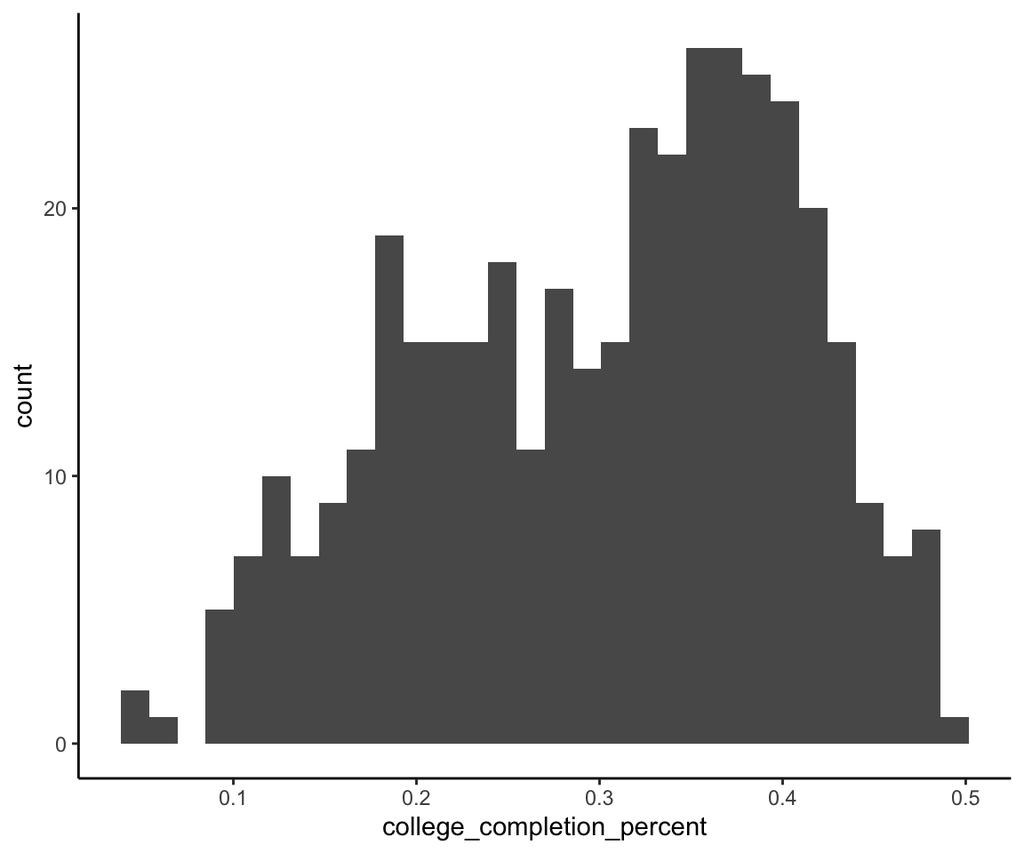

```r
tract_edu_df <- raw_tract_edu_df %>%
    select(-moe) %>%
    spread(key = variable, value = estimate) %>%
    mutate(college_completion_percent = Bachelor / Total)

ggplot(tract_edu_df, aes(x=college_completion_percent)) +
    geom_histogram() +
    theme_classic()
```

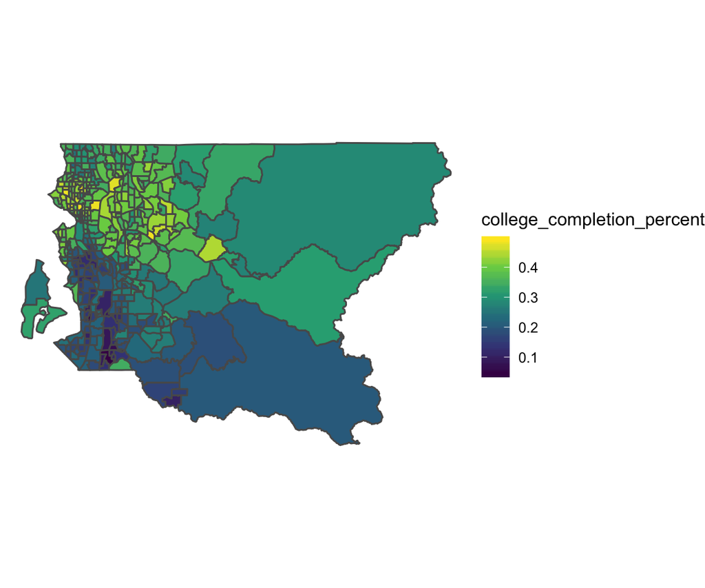

```r
ggplot(tract_edu_df) +
    geom_sf(aes(fill = college_completion_percent)) +
    scale_fill_viridis_c() +
    theme_void()
```

```r
mapview(tract_edu_df, zcol = "college_completion_percent", legend = TRUE)
```

[interactive chart not shown]

# Another example: unmarried-partner households

Table `B11009`

We can get every variable in the table at once by using the `table` argument instead of the `variable` argument.

```r
# get the table
tract_hh <- get_acs("tract",
                    table = "B11009",
                    summary_var = "B11009_001",
                    year = 2018,
                    state = "WA",
                    county = "King",
                    geometry = TRUE,
                    survey = "acs5")
```

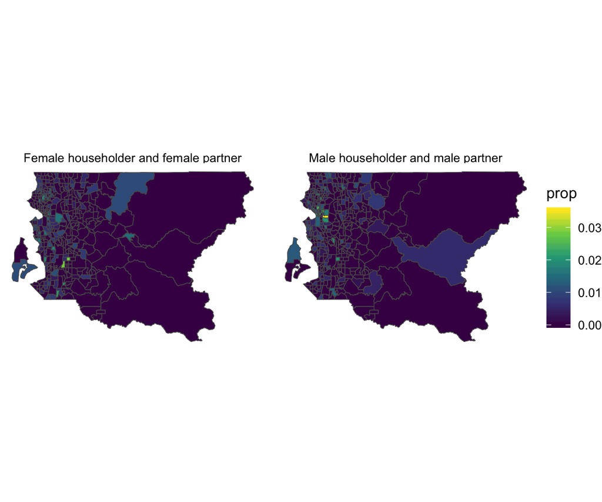

```r
# wouldn't it be nice if the variables had labels?
table_b11009 <-
    var_df %>%
    filter(str_starts(name, "B11009")) %>%
    mutate(short_label = str_split(label, "!!"),
           short_label = map_chr(short_label, tail, 1)) %>%
    select(name, short_label)

tract_hh <-
    tract_hh %>%
    left_join(table_b11009, by = c("variable" = "name"))

# calculate proportions
tract_hh_prop <-
    tract_hh %>%
    mutate(prop = estimate/summary_est,
           prop_moe = moe_prop(estimate, summary_est,
                               moe, summary_moe))
# make a map
tract_hh_prop %>%
    filter(short_label %in% c(
        "Male householder and male partner",
        "Female householder and female partner"
    )) %>%
    ggplot() +
    geom_sf(aes(fill = prop), size = .25) +
    facet_wrap(vars(short_label)) +
    scale_fill_viridis_c() +
    theme_void()
```

# Working with geometries using `tigris`

The `tidycensus` package uses the `tigris` package under the hood to get the geometries for spatial units, but not every kind of unit is covered. For those that aren’t, you can use `tigris` directly. For instance, here’s how to get the boundaries for a certain place called “Seattle”:

```r
library(tigris)
```

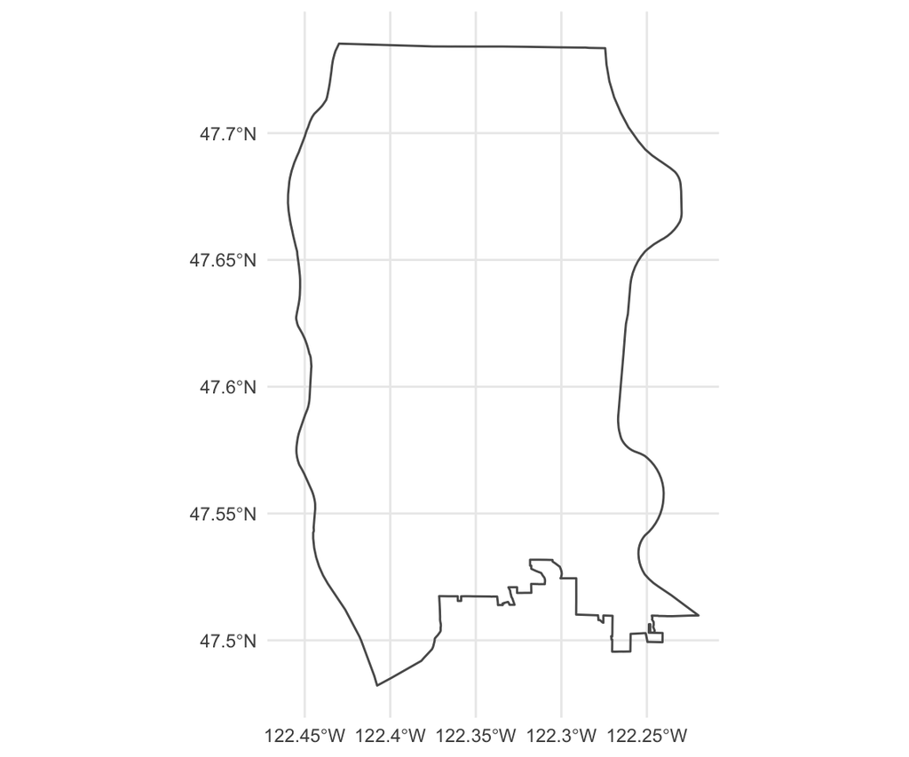

```r
options(tigris_use_cache = TRUE)

# load places in Washington
wa <- places("WA", year = 2018, class = "sf")

# filter to Seattle
seattle <-
    wa %>%
    filter(NAME == "Seattle")

ggplot(seattle) +
    geom_sf(fill = "transparent") +
    theme_minimal()
```

Doesn’t that shape look familiar? No?

Let’s *intersect* it with the King County tracts:

```r
# TODO: figure out how to fix the various warnings
# https://gis.stackexchange.com/questions/303126/how-to-buffer-a-pair-of-longitude-and-latitude-coordinates-in-r
seattle_tracts <- st_intersection(st_buffer(tract_hh_prop, 1e-5), seattle)
```

```
## dist is assumed to be in decimal degrees (arc_degrees).
```

```
## although coordinates are longitude/latitude, st_intersection assumes that they are planar
```

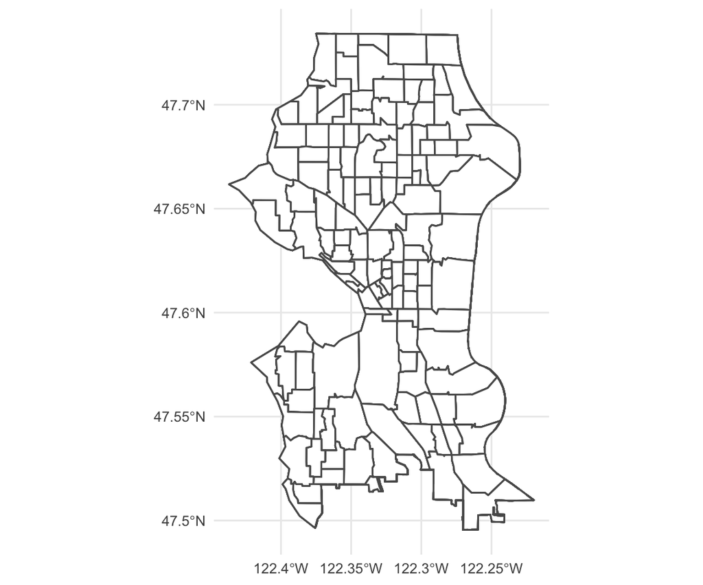

```r
ggplot(seattle_tracts) +
    geom_sf(fill = "white") +
    theme_minimal()
```

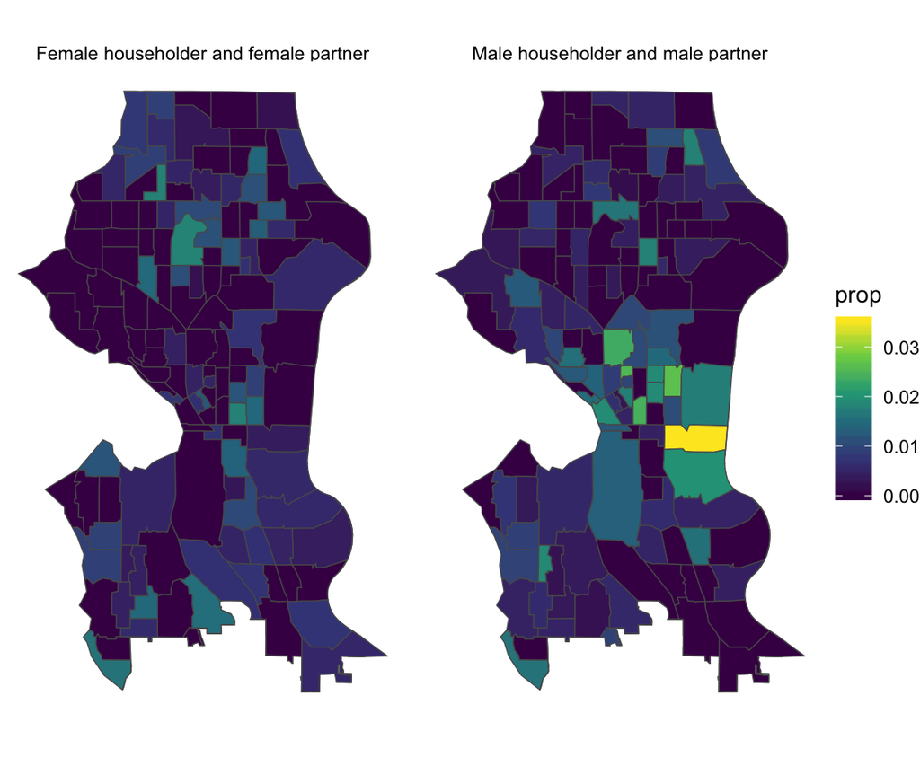

```r
seattle_tracts %>%
    filter(short_label %in% c(
        "Male householder and male partner",
        "Female householder and female partner"
    )) %>%
    ggplot() +
    geom_sf(aes(fill = prop), size = .25) +
    facet_wrap(vars(short_label)) +
    scale_fill_viridis_c() +
    theme_void()
```